# Echinoderms only - 66 CS

2023-10-11

## Script to work on analyses for causes paper

##Taxonomic work is needed? # Morpho differentiation types: More CS sl than CS ss overall? # Need to find expectations and test against 50:50 mark

```
##
##  Pearson's Chi-squared test with Yates' continuity correction
##
## data:  cbind(expected, observed)
## X-squared = 1.0128, df = 1, p-value = 0.3142
```

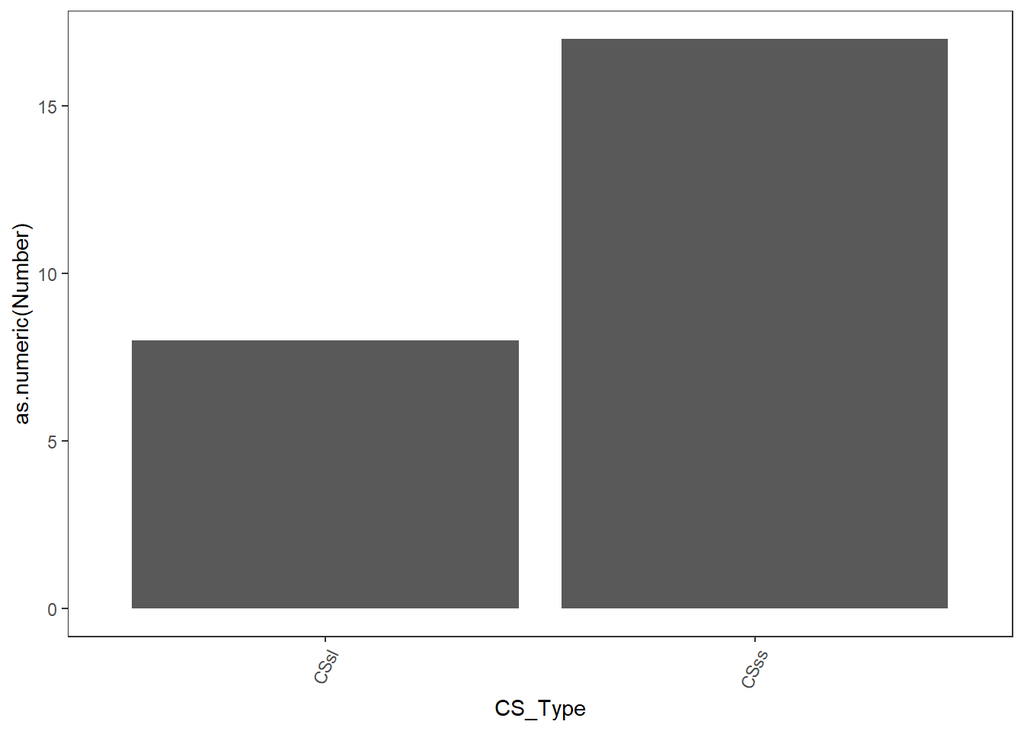

More CSss than the 50% benchmark (but not significant), so reject the idea that most CS are just due to taxonomic oversight.

# Available technology – More diagnostic differences in species described earlier?

```
##
##        FALSE TRUE
##   1750     0    1
##   1770     0    1
##   1780     0    1
##   1800     1    0
##   1820     2    0
##   1830     1    2
##   1840     1    0
##   1860     0    1
##   1870     0    4
##   1890     0    1
##   1970     0    1
```

```
##
##  Pearson's Chi-squared test
##
## data:  decademorpho$decade and decademorpho$CSss
## X-squared = 13.789, df = 10, p-value = 0.1828
```

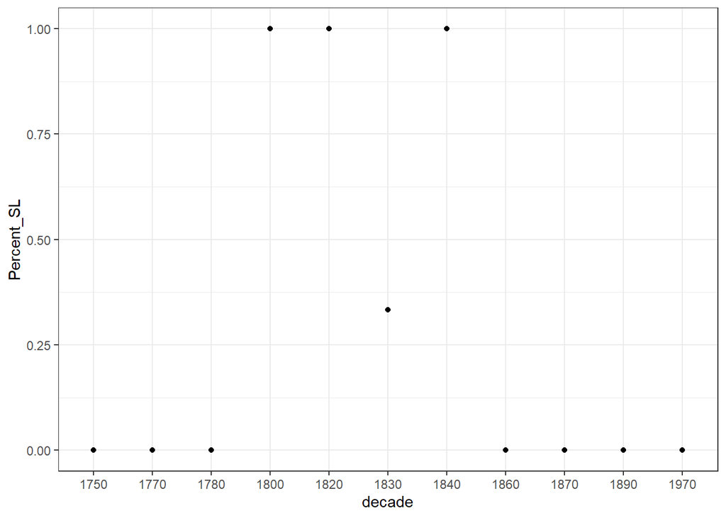

There is no trend in the percent of CSsl (diagnostic differences) through time; hypothesis not supported. Note VERY small sample size.

# Prevailing theories of nature and species origins - More CS in fragmented habitats in species described before Darwin?

```
##
##             10 100 1000 25  5
##   1756-1859  5   2    1 13  6
##   1860-1980  1   8    0  7  4
##   1981-2020  1   0    0  0  0
```

```
##
##  Pearson's Chi-squared test
##
## data:  breaks_HKK$decade_bin and breaks_HKK$HKK
## X-squared = 14.54, df = 8, p-value = 0.06872
```

```
##                   10        100       1000        25         5
## pre_Darwin 0.1851852 0.07407407 0.03703704 0.4814815 0.2222222
## pre_Kimura 0.0500000 0.40000000 0.00000000 0.3500000 0.2000000
## modern     1.0000000 0.00000000 0.00000000 0.0000000 0.0000000
```

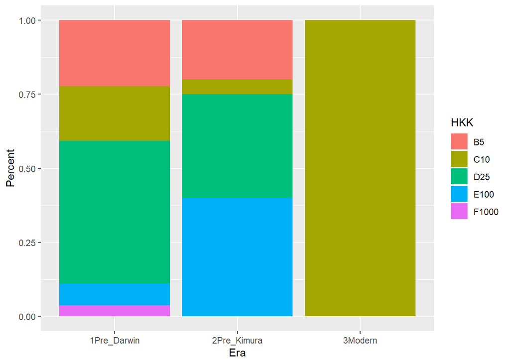

There’s marginal support here. Note that only one species is in the “modern” bin. So there’s more HKK=5 and =10 in the early bin, and more HKK = 100 in the later one. Again, tiny sample sizes though.

# Accessibility of habitat when species described - Percentage of CS in inaccessible habitats higher in earlier spp?

```
##
##        Difficult Easy Normal
##   1750         0    1      3
##   1770         1    0      1
##   1780         0    0      1
##   1800         0    1      1
##   1810         0    1      1
##   1820         0    1      2
##   1830         0    1      3
##   1840         1    0      7
##   1850         0    1      3
##   1860         1    2      3
##   1870         5    1      1
##   1880         1    0      1
##   1890         0    0      3
##   1900         0    0      2
##   1910         1    0      0
##   1970         0    1      0
##   2000         0    0      1
```

```
##
##  Pearson's Chi-squared test
##
## data:  decadeAccess$decade and decadeAccess$Access
## X-squared = 38.619, df = 32, p-value = 0.1953
```

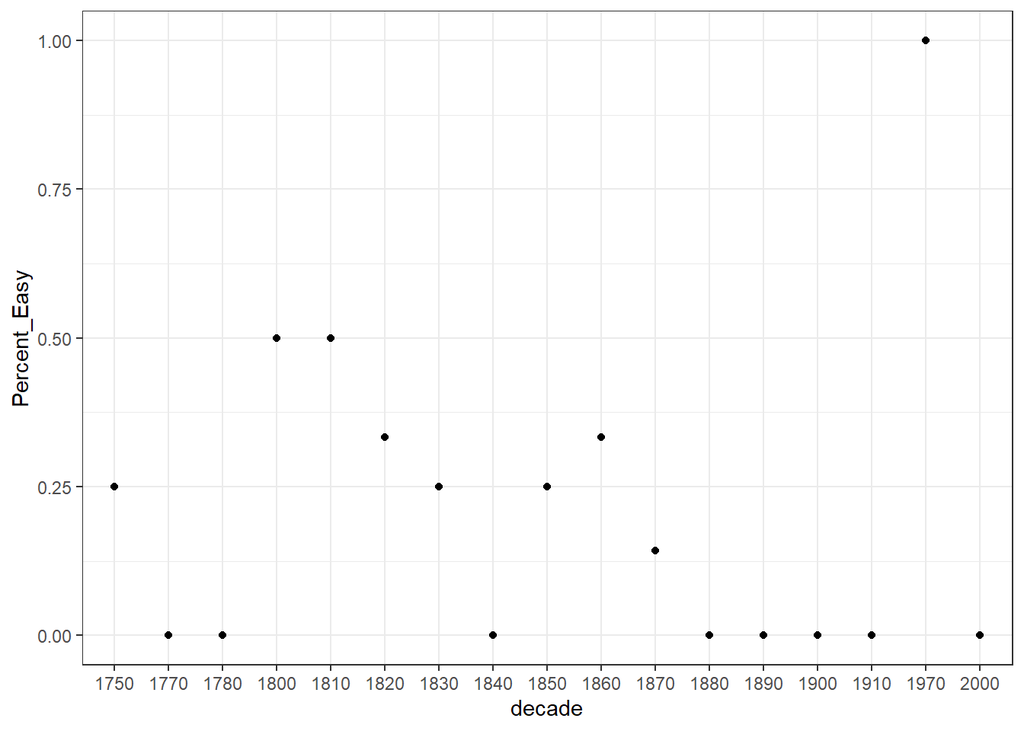

So the result is not significant but the graph is very much in line with our predictions - easy species mostly described early.

## In sum, when we only look at species with CS (i.e. our database), the effect of taxonomic work goes away. This is interesting since that was the strongest effect in paper 1. Seems to still be true with the echinoderms, and again note very very small sample sizes - only 17 species have both a date of description and morpho data.

## Effect of recent divergence - dispersal

# Larval type – Planktotrophic/pelagic larvae leads to less CS/NS)?

Note1: for this I’m working with a separate surveylarv input file where I have corrected larval types to pt, lt, dd, and removed all others, including cases where there are multiple types checked. (Most of those cases are where the two CS have different larvae.) This left 45 CS with larval info.

Note2: the data fail the homoscedasticity test (Bartlett’s) so I’ve used a nonparametric Kruskal-Wallis test to see if CS/NS is different among groups.

```
##       DD       LT       PT
## 3.363636 3.636364 2.608696
```

```
##       DD       LT       PT
## 1.747726 2.335497 1.196173
```

```
##
##  Kruskal-Wallis rank sum test
##
## data:  as.numeric(larv_NbCS$Nb_CS) and larv_NbCS$Larv_type
## Kruskal-Wallis chi-squared = 3.0858, df = 2, p-value = 0.2138
```

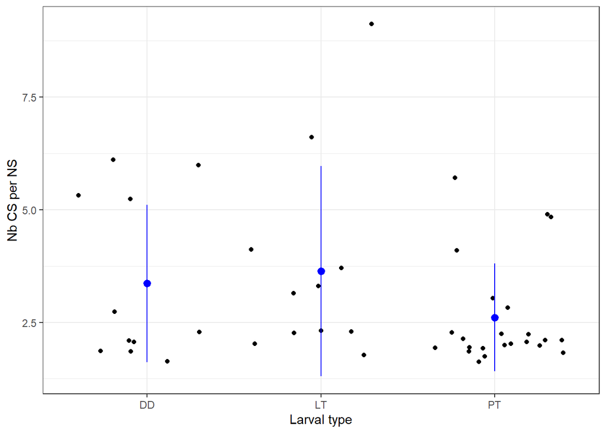

Hypothesis not supported.

# High HKK leads to more CS ss – testing this based on Nb_CS per HKK.

Note: data again failed homoscedasticity, using Kruskal Wallis test

```
##        5       10       25      100     1000
## 2.714286 2.750000 3.166667 3.272727 2.000000
```

```
##        5       10       25      100     1000
## 1.325987 1.164965 1.970801 1.848833       NA
```

```
##
##  Kruskal-Wallis rank sum test
##
## data:  HKK_NbCS$Nb_CS and HKK_NbCS$HKKv3
## Kruskal-Wallis chi-squared = 1.3778, df = 4, p-value = 0.848
```

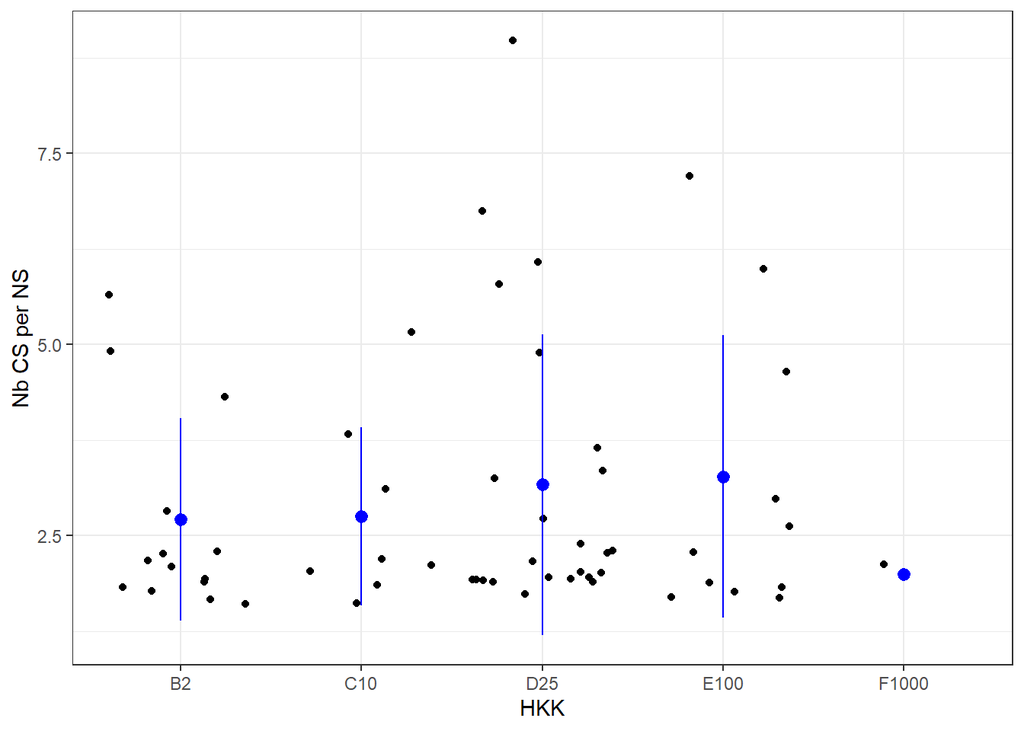

Result: Hypothesis not supported.

## In sum, NO support for the role of recent divergence as measured by a proxy of dispersal when considering only echinoderms.

# More stable environments = more CSss or statistical differences

Note: stable = pelagic, deepsea, cave, coralreef; not stable = coastal, intertidal, estuarine, seagrass

```
##
##         FALSE TRUE
##   FALSE     6    2
##   TRUE     12    5
```

```
##
##  Pearson's Chi-squared test with Yates' continuity correction
##
## data:  stable_hab$CSss and stable_hab$Stable
## X-squared = 0, df = 1, p-value = 1
```

```
##                FALSE      TRUE
## CSss_total 0.6666667 0.7142857
## CSsl_total 0.3333333 0.2857143
```

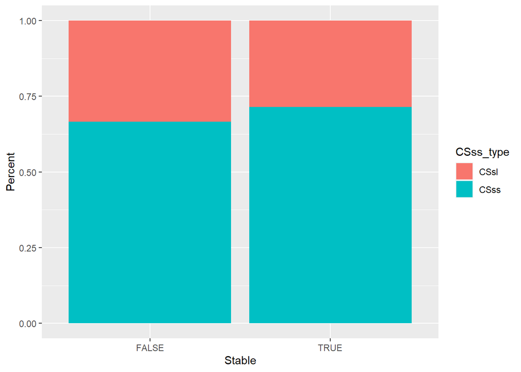

Result: More CSss NOT found in stable environments. Hypothesis NOT supported.

# Note also that stabilizing selection predicts more CSss than CSsl, which is not what we find (see above; find no difference between groups).

## In sum, we have no support for this idea within the echinoderms.

## High Ne (neutral hypotheses)

# Reproductive investment - Low reproductive investment leads to more statistical divergence? (Repro. investment proxy for Ne)

Note1: Again this uses the surveylarv dataset with hand cleaning. Note2: Planktotrophic = LOW; Lecithotrophic, Brooding, DD = HIGH; If a spp could be both low and high, have marked it NA (is usually bc the CS have different larval types). Anything else got marked NA to be conservative. Note3: Only 19 cases are considered here, meaning that is where we have morphological data AND larval type data AND echinoderms! Small sample size!

```
##
##                      HIGH LOW
##   Diagnostic            3   3
##   No differentiation    1   2
##   Statistic             7   3
```

```
##
##  Pearson's Chi-squared test
##
## data:  surveylarv2$Morpho_diff and surveylarv2$Repro_invest
## X-squared = 1.497, df = 2, p-value = 0.4731
```

```
##                  HIGH   LOW
## stat_total 0.63636364 0.375
## diag_total 0.27272727 0.375
## nod_total  0.09090909 0.250
```

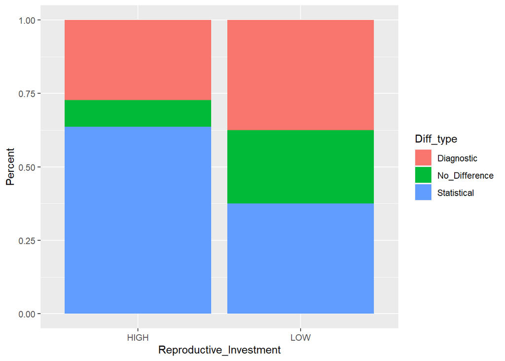

Result: Hypothesis not supported. We do see more diagnostic differences at low RI but the sample sizes are very low and the result is not significant.

# High HKK leads to more CS ss (HKK as proxy for Ne)

```
##
##                      5 10 25 100
##   Diagnostic         3  2  0   1
##   No differentiation 1  2  1   0
##   Statistic          4  1  4   2
```

```
##                5  10  25       100
## stat_total 0.500 0.2 0.8 0.6666667
## diag_total 0.375 0.4 0.0 0.3333333
## nod_total  0.125 0.4 0.2 0.0000000
```

```
##
##   5  10  25 100
##   8   5   5   3
```

```
##
##  Pearson's Chi-squared test
##
## data:  surveymorpho$Morpho_diff and surveymorpho$HKKv3
## X-squared = 5.665, df = 6, p-value = 0.4617
```

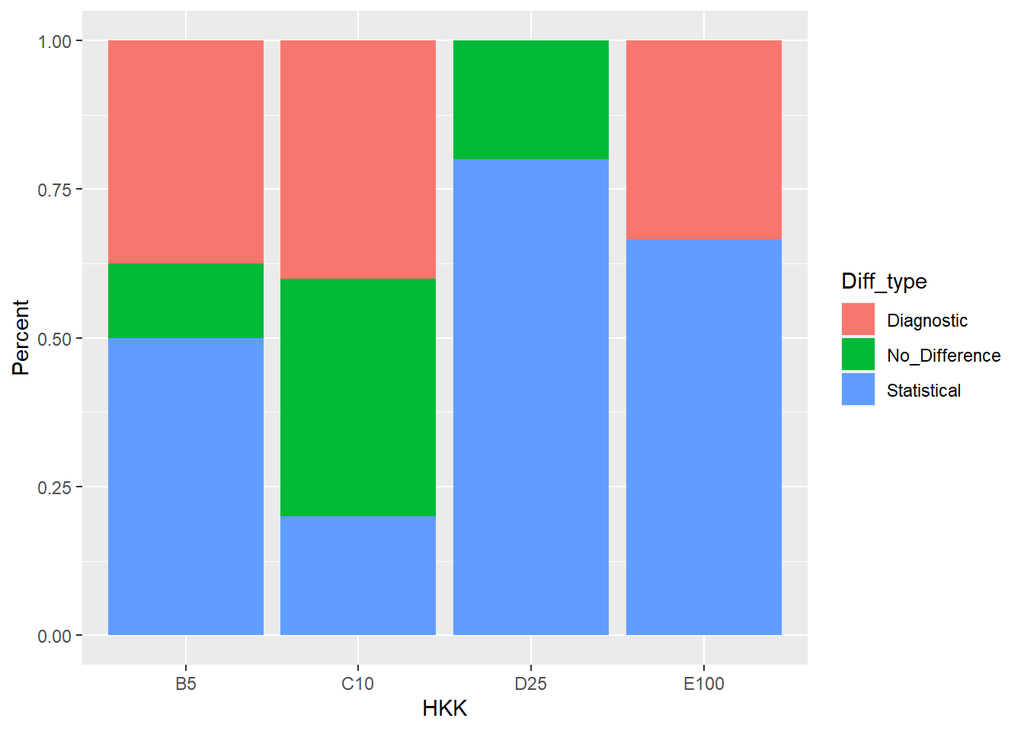

```
##
##       FALSE TRUE
##   5       3    5
##   10      2    3
##   25      0    5
##   100     1    2
```

```
##
##  Pearson's Chi-squared test
##
## data:  surveymorpho$HKKv3 and surveymorpho$CSss
## X-squared = 2.6658, df = 3, p-value = 0.4461
```

```
##                5  10 25       100
## CSss_total 0.625 0.6  1 0.6666667
## CSsl_total 0.375 0.4  0 0.3333333
```

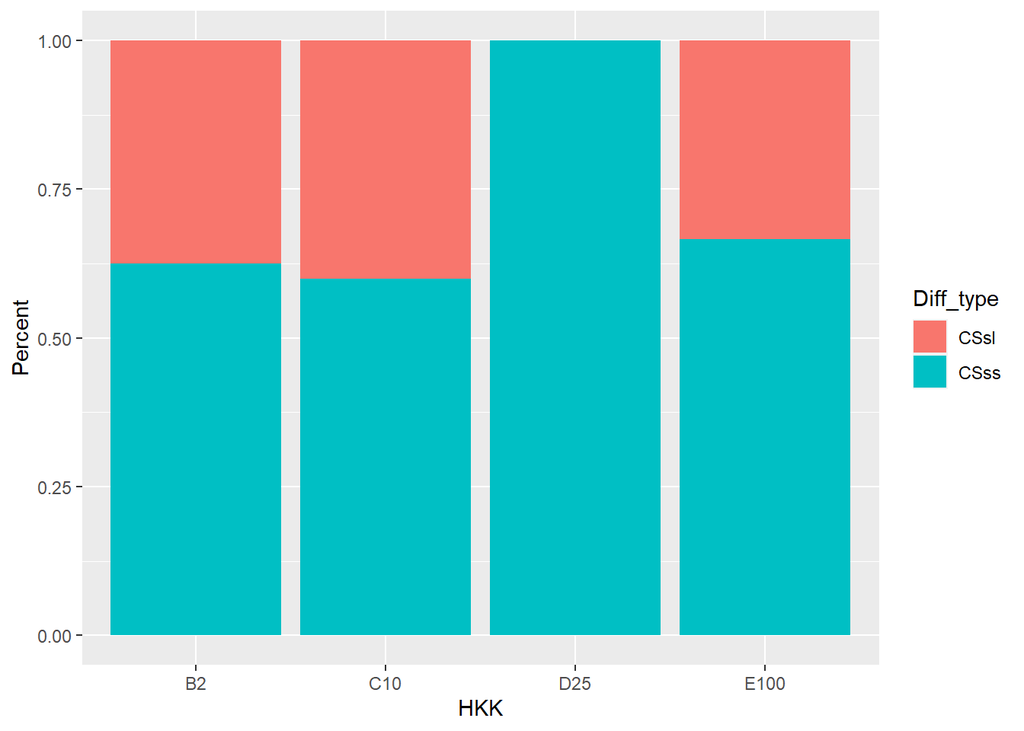

## In sum, we see NO support for the neutral hypothesis with either reproductive investment and HKK.

## Hypothesis: effect of recent divergence – More sympatric than allopatric CS/NS for a given Nsg?

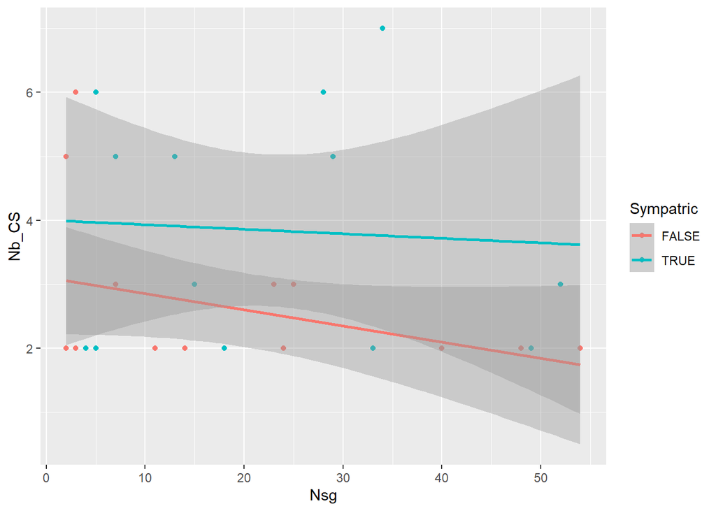

```
## ANOVA Table (type II tests)
##
##      Effect DFn DFd     F     p p<.05   ges
## 1     Nb_CS   1  27 1.267 0.270       0.045
## 2 Sympatric   1  27 0.507 0.483       0.018
```

These results aren’t statistically significant (ANCOVA) but the graph is in line with the hypothesis. HOWEVER, error overlaps a lot. Marginal support.

## Selection against hybrids – More diagnostic differences in sympatry than allopatry?

```
##
##         FALSE TRUE
##   FALSE     6    2
##   TRUE      7    5
```

```
##
##  Pearson's Chi-squared test with Yates' continuity correction
##
## data:  surveymorpho$CSss and surveymorpho$Sympatric
## X-squared = 0.082418, df = 1, p-value = 0.774
```

```
##                FALSE      TRUE
## CSss_total 0.5384615 0.7142857
## CSsl_total 0.4615385 0.2857143
```

[figure not shown]

Result: Not supported. Very small sample size here, just 20 cases.

## Importance of biological traits

# More diagnostic traits with hard skeleton?

```
##
##                       N  Y
##   Diagnostic          0  8
##   No differentiation  0  5
##   Statistic           0 12
```

```
##              N    Y
## stat_total NaN 0.48
## diag_total NaN 0.32
## nod_total  NaN 0.20
```

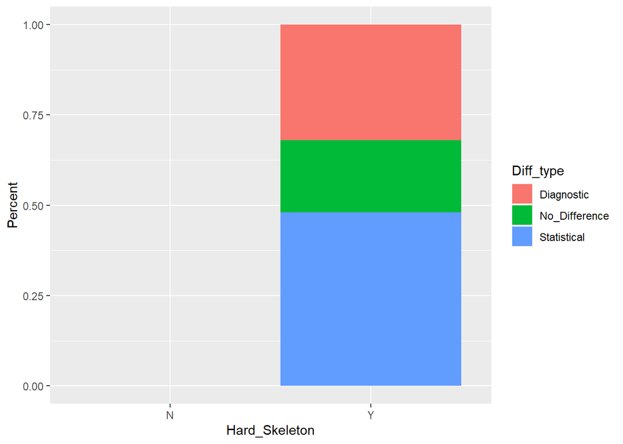

No test; everyone has hard skeleton.

# More diagnostic traits with image vision?

```
##
##                       N  Y
##   Diagnostic          8  0
##   No differentiation  5  0
##   Statistic          12  0
```

No test; no one has image vision.

# More diagnostic traits with internal fertilization?

```
##
##                       B  E  I
##   Diagnostic          0  8  0
##   No differentiation  0  5  0
##   Statistic           0 12  0
```

```
##              B    E   I
## stat_total NaN 0.48 NaN
## diag_total NaN 0.32 NaN
## nod_total  NaN 0.20 NaN
```

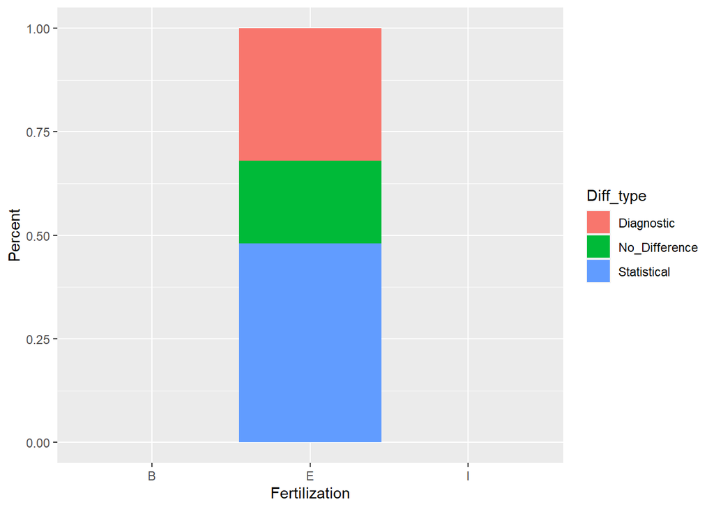

Result: No test; everyone has external fertilization.

# More diagnostic traits with external genitalia?

```
##
##                       B  N  Y
##   Diagnostic          0  8  0
##   No differentiation  0  5  0
##   Statistic           0 12  0
```

```
##              B    N   Y
## stat_total NaN 0.48 NaN
## diag_total NaN 0.32 NaN
## nod_total  NaN 0.20 NaN
```

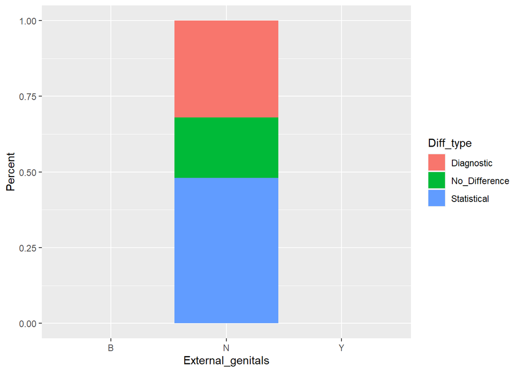

Result: No test; no one has genitalia.